# Lesson 5: Normal Distributions

Homework

- Word Document
- PDF Document

## Solutions

**Please note that the steps show rounded numbers, but that the final answers to the problems are calculated without rounding.**

Problem

Part

Solution

1

-

b. We can conclude that the data are not normal.

2

-

a. We can conclude that the data are normal.

3

-

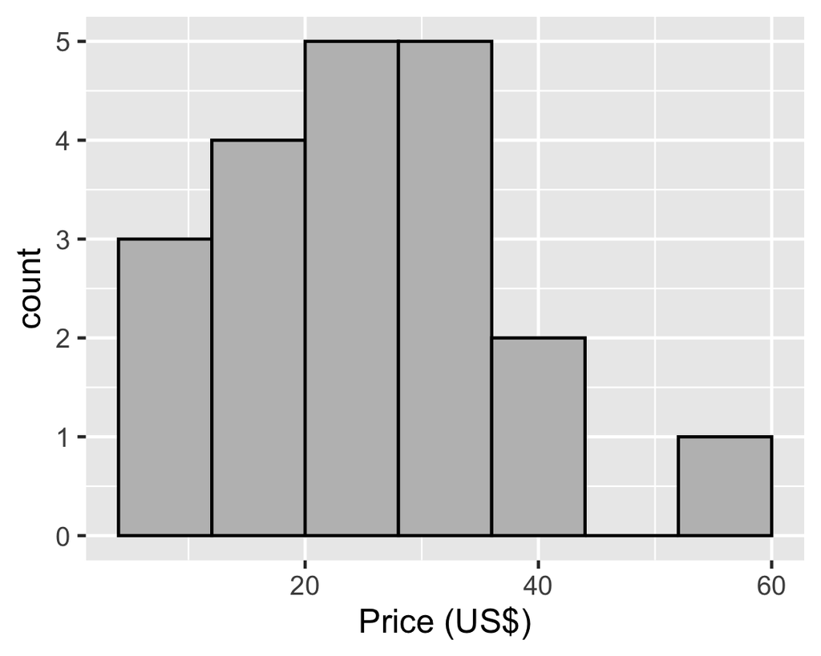

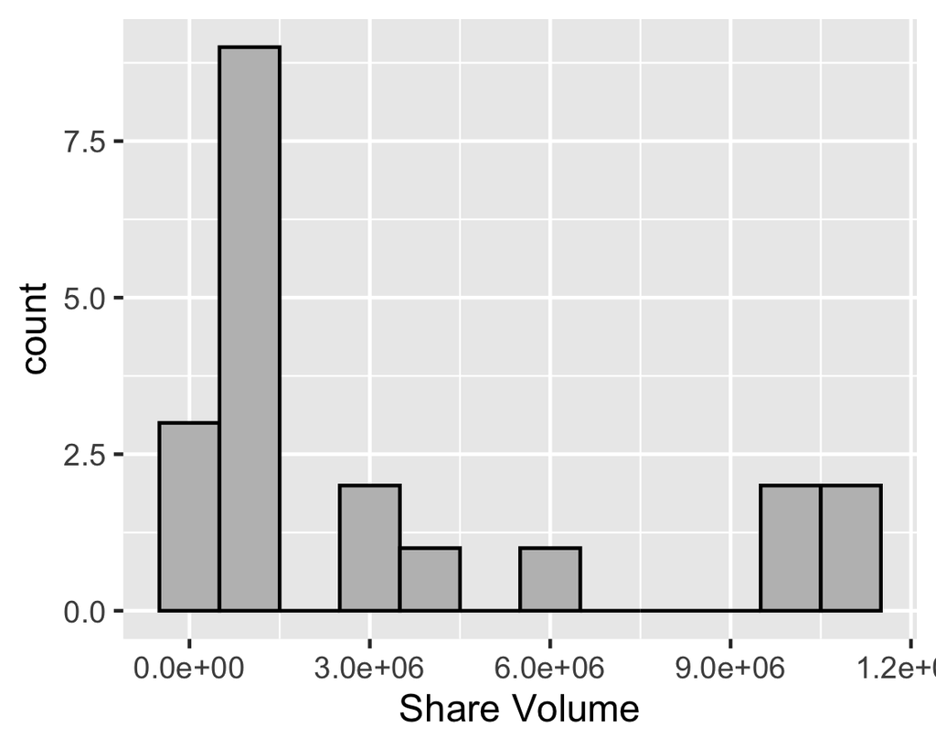

b. Out of the two variables Price and Share Volume, the volume shows a more distinct non-normal trend.

4

-

b. False

5

-

a. True

6

-

a. Always has a total area under it equal to one

7

-

b. The observed value is less than the mean.

8

-

c. 95% of all data values fall within two standard deviations of the mean.

9

-

16%

10

-

a. Right skewed

11

-

$z = -3.15$

12

-

d. The man has an unusually large shoe size.

13

-

Eleanor’s z-score: 1.8  
Gerald’s z-score: 1.5

14

-

Eleanor has the higher score based on the higher z-score which factors in the mean and standard deviation when computing the scores. Eleanor’s score has a higher percentile than Gerald’s score.

15

-

b. 88.5 and 91.5 grams.

16

-

0.001

17

-

0.042

18

-

90.309

19

-

The candy bar is heavier than 66% of all other candy bars and lighter than 34% of all candy bars.